# Texas Chronic Disease Risk Factor Analysis

Author

Michael Serna

```r
library(tidyverse)
library(knitr)
library(modelsummary)
library(broom)
library(scales)

df <- read_csv("../data_processed/tx_health_panel_places_svi.csv")

dir.create("../tables", showWarnings = FALSE)
```

# Introduction

Chronic disease risk is not evenly distributed across Texas counties. Diabetes, obesity, smoking, insurance access, and socioeconomic vulnerability vary across place, producing unequal public health burdens.

This report analyzes county-level chronic disease patterns in Texas using health indicators and social vulnerability measures. The central question is:

**What county-level health and socioeconomic factors are associated with higher diabetes prevalence in Texas?**

# Data and Measures

The analysis uses a county-level dataset combining chronic disease indicators with social vulnerability measures.

Key variables include:

```r
variable_table <- tibble(
  Variable = c(
    "diabetes",
    "obesity",
    "smoking",
    "uninsured",
    "ep_pov150",
    "ep_unemp",
    "ep_nohsdp",
    "rpl_themes"
  ),
  Description = c(
    "Estimated diabetes prevalence",
    "Estimated obesity prevalence",
    "Estimated smoking prevalence",
    "Estimated uninsured rate",
    "Percent below 150% of poverty",
    "Unemployment measure",
    "Percent without high school diploma",
    "Overall social vulnerability percentile ranking"
  )
)

kable(variable_table)
```

| Variable | Description |
| --- | --- |
| diabetes | Estimated diabetes prevalence |
| obesity | Estimated obesity prevalence |
| smoking | Estimated smoking prevalence |
| uninsured | Estimated uninsured rate |
| ep_pov150 | Percent below 150% of poverty |
| ep_unemp | Unemployment measure |
| ep_nohsdp | Percent without high school diploma |
| rpl_themes | Overall social vulnerability percentile ranking |

# Summary Statistics

```r
summary_stats <- df %>%
  select(
    diabetes,
    obesity,
    smoking,
    uninsured,
    ep_pov150,
    ep_unemp,
    ep_nohsdp,
    rpl_themes
  ) %>%
  summary()

summary_stats
```

```
    diabetes        obesity         smoking        uninsured
 Min.   : 9.05   Min.   :29.75   Min.   : 9.15   Min.   :10.20
 1st Qu.:12.05   1st Qu.:35.55   1st Qu.:13.35   1st Qu.:15.45
 Median :13.35   Median :37.45   Median :15.10   Median :18.35
 Mean   :13.60   Mean   :37.58   Mean   :14.91   Mean   :20.69
 3rd Qu.:14.80   3rd Qu.:39.55   3rd Qu.:16.30   3rd Qu.:24.80
 Max.   :22.45   Max.   :47.85   Max.   :22.55   Max.   :43.60
 NA's   :1       NA's   :1       NA's   :1       NA's   :1
   ep_pov150        ep_unemp        ep_nohsdp       rpl_themes
 Min.   : 2.60   Min.   : 0.000   Min.   : 3.20   Min.   :0.0267
 1st Qu.:20.00   1st Qu.: 3.100   1st Qu.:11.90   1st Qu.:0.5705
 Median :25.60   Median : 4.500   Median :15.30   Median :0.7587
 Mean   :25.76   Mean   : 4.773   Mean   :17.05   Mean   :0.7065
 3rd Qu.:30.48   3rd Qu.: 5.900   3rd Qu.:20.50   3rd Qu.:0.9048
 Max.   :60.90   Max.   :14.300   Max.   :66.70   Max.   :0.9994
```

# Correlation Analysis

```r
cor_vars <- df %>%
  select(
    diabetes,
    obesity,
    smoking,
    uninsured,
    ep_pov150,
    ep_unemp,
    ep_nohsdp,
    rpl_themes
  )

cor_matrix <- cor(cor_vars, use = "complete.obs")

write_csv(
  as.data.frame(cor_matrix),
  "../tables/report_correlation_matrix.csv"
)

kable(round(cor_matrix, 2))
```

|  | diabetes | obesity | smoking | uninsured | ep_pov150 | ep_unemp | ep_nohsdp | rpl_themes |
| --- | --- | --- | --- | --- | --- | --- | --- | --- |
| diabetes | 1.00 | 0.85 | 0.60 | 0.82 | 0.85 | 0.27 | 0.69 | 0.58 |
| obesity | 0.85 | 1.00 | 0.65 | 0.73 | 0.76 | 0.31 | 0.60 | 0.62 |
| smoking | 0.60 | 0.65 | 1.00 | 0.28 | 0.68 | 0.34 | 0.38 | 0.50 |
| uninsured | 0.82 | 0.73 | 0.28 | 1.00 | 0.67 | 0.16 | 0.85 | 0.53 |
| ep_pov150 | 0.85 | 0.76 | 0.68 | 0.67 | 1.00 | 0.31 | 0.62 | 0.67 |
| ep_unemp | 0.27 | 0.31 | 0.34 | 0.16 | 0.31 | 1.00 | 0.13 | 0.47 |
| ep_nohsdp | 0.69 | 0.60 | 0.38 | 0.85 | 0.62 | 0.13 | 1.00 | 0.47 |
| rpl_themes | 0.58 | 0.62 | 0.50 | 0.53 | 0.67 | 0.47 | 0.47 | 1.00 |

The correlation results provide an initial view of how chronic disease and socioeconomic risk factors move together across Texas counties. Positive correlations with diabetes suggest that counties with higher obesity, smoking, uninsured rates, or social vulnerability may also experience higher diabetes prevalence.

# Regression Analysis

To evaluate the relationship between chronic disease prevalence and socioeconomic risk factors, three linear regression models were estimated.

Model 1 includes obesity only. Model 2 adds smoking and uninsured rates. Model 3 adds socioeconomic vulnerability indicators, including poverty, unemployment, educational attainment, and the overall social vulnerability ranking.

```r
model1 <- lm(diabetes ~ obesity, data = df)

model2 <- lm(diabetes ~ obesity + smoking + uninsured, data = df)

model3 <- lm(
  diabetes ~ obesity +
    smoking +
    uninsured +
    ep_pov150 +
    ep_unemp +
    ep_nohsdp +
    rpl_themes,
  data = df
)

modelsummary(
  list(
    "Obesity Model" = model1,
    "Health Risk Model" = model2,
    "Full Socioeconomic Model" = model3
  ),
  stars = TRUE,
  statistic = "std.error",
  output = "markdown"
)
```

Obesity Model

Health Risk Model

Full Socioeconomic Model

(Intercept)

-10.614***

-1.947*

1.002

(0.955)

(0.955)

(0.882)

obesity

0.644***

0.219***

0.143***

(0.025)

(0.038)

(0.035)

smoking

0.262***

0.171***

(0.036)

(0.039)

uninsured

0.166***

0.183***

(0.012)

(0.018)

ep_pov150

0.095***

(0.010)

ep_unemp

0.024

(0.022)

ep_nohsdp

-0.051***

(0.013)

rpl_themes

-1.194***

(0.300)

Num.Obs.

253

253

253

R2

0.721

0.842

0.889

R2 Adj.

0.719

0.840

0.886

AIC

804.6

664.2

582.0

BIC

815.2

681.9

613.8

Log.Lik.

-399.298

-327.111

-281.986

F

647.136

442.502

281.582

RMSE

1.17

0.88

0.74

- p < 0.1, * p < 0.05, ** p < 0.01, *** p < 0.001

```r
modelsummary(
  list(
    "Obesity Model" = model1,
    "Health Risk Model" = model2,
    "Full Socioeconomic Model" = model3
  ),
  stars = TRUE,
  statistic = "std.error",
  output = "../tables/report_regression_models.html"
)

modelsummary(
  list(
    "Obesity Model" = model1,
    "Health Risk Model" = model2,
    "Full Socioeconomic Model" = model3
  ),
  stars = TRUE,
  statistic = "std.error",
  output = "../tables/report_regression_models.docx"
)
```

# Substantive Findings

The regression results show that obesity is strongly associated with diabetes prevalence across Texas counties. This relationship remains important even after adding smoking, uninsured status, poverty, unemployment, education, and social vulnerability measures.

The full socioeconomic model provides the most complete explanation because it connects health behaviors with broader structural conditions. Counties with higher social vulnerability are more likely to face overlapping risks related to poverty, health access, and chronic disease burden.

Substantively, the findings suggest that diabetes prevalence should not be interpreted only as an individual health behavior issue. Instead, diabetes risk appears connected to county-level social and economic conditions.

# Model Fit

```r
fit_table <- tibble(
  Model = c("Obesity Model", "Health Risk Model", "Full Socioeconomic Model"),
  R_Squared = c(
    summary(model1)$r.squared,
    summary(model2)$r.squared,
    summary(model3)$r.squared
  ),
  Adjusted_R_Squared = c(
    summary(model1)$adj.r.squared,
    summary(model2)$adj.r.squared,
    summary(model3)$adj.r.squared
  ),
  AIC = c(AIC(model1), AIC(model2), AIC(model3)),
  BIC = c(BIC(model1), BIC(model2), BIC(model3))
)

write_csv(fit_table, "../tables/report_model_fit_summary.csv")

kable(
  fit_table %>%
    mutate(across(where(is.numeric), round, 3))
)
```

| Model | R_Squared | Adjusted_R_Squared | AIC | BIC |
| --- | --- | --- | --- | --- |
| Obesity Model | 0.721 | 0.719 | 804.596 | 815.196 |
| Health Risk Model | 0.842 | 0.840 | 664.223 | 681.890 |
| Full Socioeconomic Model | 0.889 | 0.886 | 581.972 | 613.773 |

The model fit statistics compare how much explanatory power is gained as additional predictors are added. The full socioeconomic model is preferred because it includes both behavioral health measures and broader contextual indicators.

# Predicted Versus Observed Diabetes

```r
df_predictions <- df %>%
  mutate(
    predicted_diabetes = predict(model3, newdata = df),
    residual = diabetes - predicted_diabetes
  )

write_csv(
  df_predictions,
  "../tables/report_diabetes_model_predictions.csv"
)
```

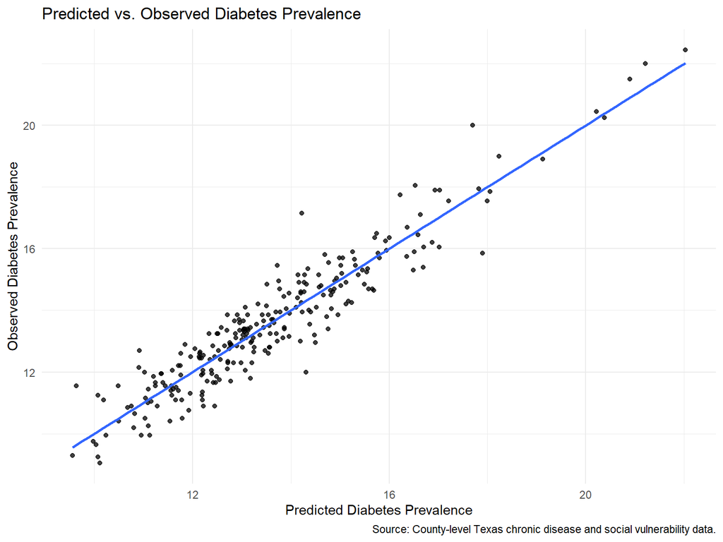

```r
ggplot(df_predictions, aes(x = predicted_diabetes, y = diabetes)) +
  geom_point(alpha = 0.75) +
  geom_smooth(method = "lm", se = FALSE) +
  labs(
    title = "Predicted vs. Observed Diabetes Prevalence",
    x = "Predicted Diabetes Prevalence",
    y = "Observed Diabetes Prevalence",
    caption = "Source: County-level Texas chronic disease and social vulnerability data."
  ) +
  theme_minimal()
```

The predicted versus observed plot evaluates how closely the model estimates actual diabetes prevalence. Counties near the fitted line are well explained by the model, while counties farther away may have additional local factors affecting diabetes risk.

# High-Residual Counties

High-residual counties are counties where observed diabetes prevalence is higher than predicted by the model. These counties may represent places where additional public health, healthcare access, or local structural factors are contributing to elevated diabetes burden.

```r
high_residual <- df_predictions %>%
  arrange(desc(residual)) %>%
  select(
    county,
    diabetes,
    predicted_diabetes,
    residual,
    obesity,
    smoking,
    uninsured,
    ep_pov150,
    rpl_themes
  ) %>%
  slice_head(n = 10)

write_csv(high_residual, "../tables/report_high_residual_counties.csv")

kable(
  high_residual %>%
    mutate(across(where(is.numeric), round, 2))
)
```

| county | diabetes | predicted_diabetes | residual | obesity | smoking | uninsured | ep_pov150 | rpl_themes |
| --- | --- | --- | --- | --- | --- | --- | --- | --- |
| Jeff Davis | 17.15 | 14.22 | 2.93 | 37.95 | 14.65 | 18.65 | 33.0 | 0.47 |
| Presidio | 20.00 | 17.70 | 2.30 | 41.75 | 15.40 | 35.15 | 46.8 | 0.99 |
| Fort Bend | 11.55 | 9.63 | 1.92 | 29.75 | 9.65 | 12.80 | 12.7 | 0.45 |
| Terrell | 12.70 | 10.92 | 1.78 | 34.05 | 9.60 | 17.15 | 7.0 | 0.09 |
| Marion | 15.45 | 13.73 | 1.72 | 39.10 | 18.10 | 14.30 | 28.2 | 0.73 |
| Culberson | 17.75 | 16.23 | 1.52 | 40.55 | 16.50 | 31.65 | 28.7 | 0.84 |
| San Augustine | 18.05 | 16.53 | 1.52 | 43.70 | 22.35 | 18.25 | 41.1 | 0.99 |
| Menard | 14.85 | 13.51 | 1.34 | 37.05 | 14.50 | 21.40 | 27.2 | 0.86 |
| Mason | 12.15 | 10.91 | 1.24 | 33.90 | 11.95 | 15.05 | 13.3 | 0.27 |
| Crockett | 14.95 | 13.76 | 1.19 | 37.65 | 14.35 | 28.90 | 15.4 | 0.41 |

# Figures

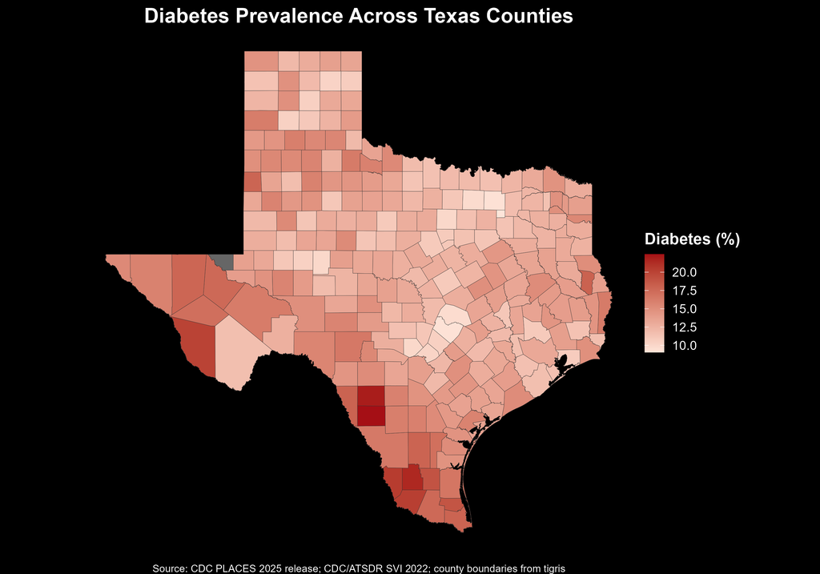

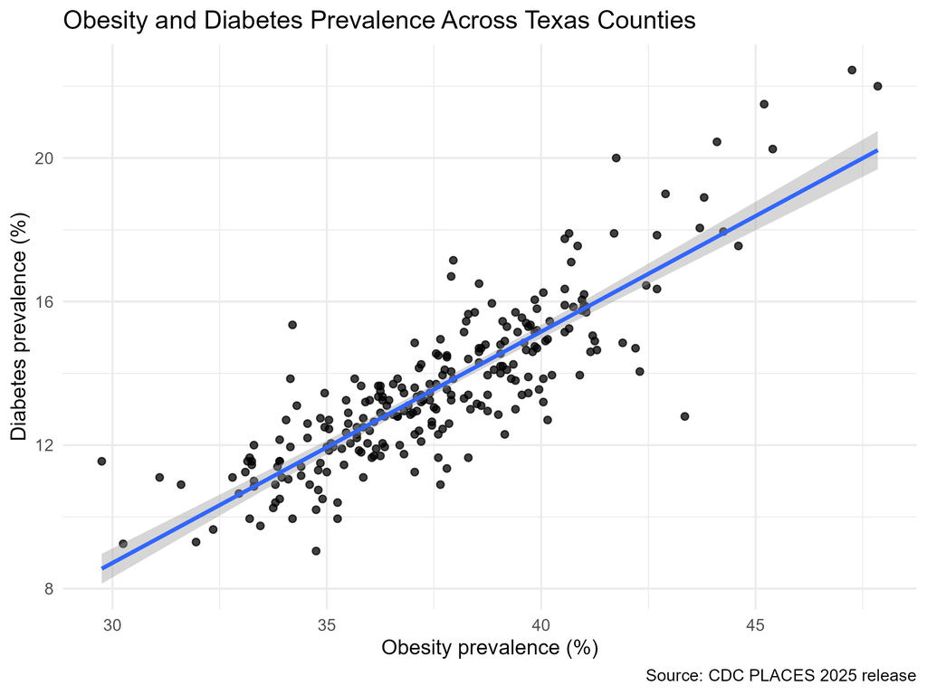

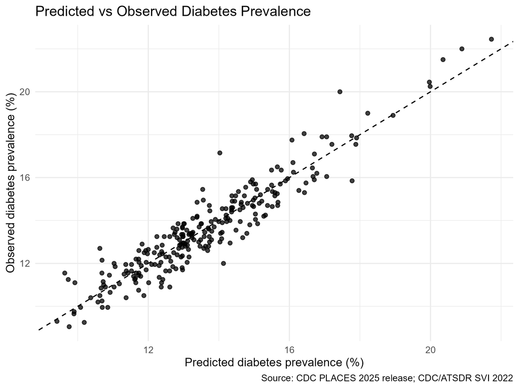

# Policy Implications

The results suggest that chronic disease intervention should be geographically targeted. Counties with high diabetes prevalence and high social vulnerability may require more than general health education campaigns. They may need coordinated interventions involving preventive care, insurance access, food access, transportation support, and local public health capacity.

This analysis supports three broad policy implications:

1. Diabetes prevention should prioritize counties with overlapping health and socioeconomic risks.
2. Obesity and smoking reduction remain important, but they should be paired with structural supports.
3. High-residual counties deserve additional investigation because their diabetes burden exceeds what the model predicts.

# Conclusion

This project finds that diabetes prevalence across Texas counties is closely related to obesity, smoking, uninsured status, and broader socioeconomic vulnerability. The strongest model combines health behavior indicators with social vulnerability measures, showing that chronic disease risk is both medical and structural.

Overall, the analysis demonstrates how county-level data can be used to identify high-risk areas, evaluate predictors of chronic disease, and support more targeted public health policy decisions.

# Appendix

## Full Model Coefficients

```r
coef_table <- tidy(model3)

write_csv(coef_table, "../tables/report_model3_coefficients.csv")

kable(
  coef_table %>%
    mutate(across(where(is.numeric), round, 4))
)
```

| term | estimate | std.error | statistic | p.value |
| --- | --- | --- | --- | --- |
| (Intercept) | 1.0015 | 0.8817 | 1.1359 | 0.2571 |
| obesity | 0.1434 | 0.0346 | 4.1409 | 0.0000 |
| smoking | 0.1712 | 0.0386 | 4.4344 | 0.0000 |
| uninsured | 0.1833 | 0.0179 | 10.2295 | 0.0000 |
| ep_pov150 | 0.0953 | 0.0103 | 9.2871 | 0.0000 |
| ep_unemp | 0.0243 | 0.0221 | 1.0987 | 0.2730 |
| ep_nohsdp | -0.0506 | 0.0126 | -4.0193 | 0.0001 |
| rpl_themes | -1.1944 | 0.2998 | -3.9838 | 0.0001 |